# WALMART SALES FORECASTING

# DEVIKA ENUGU

1. Problem Statement
2. Project Objective
3. Data Description
4. Data Pre-processing Steps and Inspiration
5. Choosing the Algorithm for the Project
6. Motivation and Reasons For Choosing the Algorithm
7. Assumptions
8. Model Evaluation and Techniques
9. Inferences from the Same
10. Future Possibilities of the Project
11. Conclusion

# 1.Problem Statement

A retail store that has multiple outlets across the country are facing issues in managing the inventory - to match the demand with respect to supply.

Dataset Information:

The walmart.csv contains 6435 rows and 8 columns.

Store --------------Store number

Date -------------- Week of Sales

Weekly_Sales --------- Sales for the given store in that week

Holiday_Flag -----------If it is a holiday week

Temperature -----------Temperature on the day of the sale

Fuel_Price -----------Cost of the fuel in the region

CPI -----------Consumer Price Index

Unemployment -----------Unemployment Rate

# 2.Project Objective

- The objective of a sales forecasting project for Walmart could be to accurately predict the sales performance of their stores or products for a specific time period in the future. This could involve analyzing historical sales data, as well as external factors such as economic conditions weather patterns, and consumer trends, to create a predictive model that can forecast future sales.
- The ultimate goal of the project would be to provide Walmart with insights that could help them optimize their inventory management, pricing, and marketing strategies to maximize sales and profits. This could involve identifying trends and patterns in consumer behavior.
- Overall, the objective of a Walmart sales forecasting project would be to provide the company with actionable insights that can help them make informed business decisions and improve their overall performance in the market.

# 3.Data Description

- walmart data include many factors as shown below

Store --------------Store number

Date -------------- Week of Sales

Weekly_Sales --------- Sales for the given store in that week

Holiday_Flag -----------If it is a holiday week

Temperature -----------Temperature on the day of the sale

Fuel_Price -----------Cost of the fuel in the region

CPI -----------Consumer Price Index

Unemployment -----------Unemployment Rate

```python
import pandas as pd
import numpy as np
import matplotlib.pyplot as plt
import warnings
warnings.filterwarnings("ignore")
```

```python
df = pd.read_csv('Walmart (1).csv')
```

```python
df.head()
```

|  | Store | Date | Weekly_Sales | Holiday_Flag | Temperature | Fuel_Price | CPI | Unemployment |
| --- | --- | --- | --- | --- | --- | --- | --- | --- |
| 0 | 1 | 05-02-2010 | 1643690.90 | 0 | 42.31 | 2.572 | 211.096358 | 8.106 |
| 1 | 1 | 12-02-2010 | 1641957.44 | 1 | 38.51 | 2.548 | 211.242170 | 8.106 |
| 2 | 1 | 19-02-2010 | 1611968.17 | 0 | 39.93 | 2.514 | 211.289143 | 8.106 |
| 3 | 1 | 26-02-2010 | 1409727.59 | 0 | 46.63 | 2.561 | 211.319643 | 8.106 |
| 4 | 1 | 05-03-2010 | 1554806.68 | 0 | 46.50 | 2.625 | 211.350143 | 8.106 |

```python
df.shape
```

```
(6435, 8)
```

```python
df.describe()
```

|  | Store | Weekly_Sales | Holiday_Flag | Temperature | Fuel_Price | CPI | Unemployment |
| --- | --- | --- | --- | --- | --- | --- | --- |
| count | 6435.000000 | 6.435000e+03 | 6435.000000 | 6435.000000 | 6435.000000 | 6435.000000 | 6435.000000 |
| mean | 23.000000 | 1.046965e+06 | 0.069930 | 60.663782 | 3.358607 | 171.578394 | 7.999151 |
| std | 12.988182 | 5.643666e+05 | 0.255049 | 18.444933 | 0.459020 | 39.356712 | 1.875885 |
| min | 1.000000 | 2.099862e+05 | 0.000000 | -2.060000 | 2.472000 | 126.064000 | 3.879000 |
| 25% | 12.000000 | 5.533501e+05 | 0.000000 | 47.460000 | 2.933000 | 131.735000 | 6.891000 |
| 50% | 23.000000 | 9.607460e+05 | 0.000000 | 62.670000 | 3.445000 | 182.616521 | 7.874000 |
| 75% | 34.000000 | 1.420159e+06 | 0.000000 | 74.940000 | 3.735000 | 212.743293 | 8.622000 |
| max | 45.000000 | 3.818686e+06 | 1.000000 | 100.140000 | 4.468000 | 227.232807 | 14.313000 |

```python
df.info()
```

```
<class 'pandas.core.frame.DataFrame'>
RangeIndex: 6435 entries, 0 to 6434
Data columns (total 8 columns):
 #   Column        Non-Null Count  Dtype
---  ------        --------------  -----
 0   Store         6435 non-null   int64
 1   Date          6435 non-null   object
 2   Weekly_Sales  6435 non-null   float64
 3   Holiday_Flag  6435 non-null   int64
 4   Temperature   6435 non-null   float64
 5   Fuel_Price    6435 non-null   float64
 6   CPI           6435 non-null   float64
 7   Unemployment  6435 non-null   float64
dtypes: float64(5), int64(2), object(1)
memory usage: 402.3+ KB
```

```python
df.isna().sum()
```

```
Store           0
Date            0
Weekly_Sales    0
Holiday_Flag    0
Temperature     0
Fuel_Price      0
CPI             0
Unemployment    0
dtype: int64
```

# 4.Data Pre-processing Steps and Inspiration

```python
df['Date'] = pd.to_datetime(df['Date'],errors='coerce')
df.sort_values(by=['Date'],inplace=True)
df.set_index(df.Date, inplace=True)
df.drop(df.Date)
df.head()
```

| Date | Store | Date | Weekly_Sales | Holiday_Flag | Temperature | Fuel_Price | CPI | Unemployment |
| --- | --- | --- | --- | --- | --- | --- | --- | --- |
| 2010-01-10 | 5 | 2010-01-10 | 283178.12 | 0 | 71.10 | 2.603 | 212.226946 | 6.768 |
| 2010-01-10 | 15 | 2010-01-10 | 566945.95 | 0 | 59.69 | 2.840 | 132.756800 | 8.067 |
| 2010-01-10 | 42 | 2010-01-10 | 481523.93 | 0 | 86.01 | 3.001 | 126.234600 | 9.003 |
| 2010-01-10 | 33 | 2010-01-10 | 224294.39 | 0 | 91.45 | 3.001 | 126.234600 | 9.265 |
| 2010-01-10 | 36 | 2010-01-10 | 422169.47 | 0 | 74.66 | 2.567 | 210.440443 | 8.476 |

```python
df.shape
```

```
(6435, 8)
```

```python
df['Year'] = df['Date'].dt.year
df['Month'] = df['Date'].dt.month
df['Week'] = df['Date'].dt.week
```

```python
df.head()
```

| Date | Store | Date | Weekly_Sales | Holiday_Flag | Temperature | Fuel_Price | CPI | Unemployment | Year | Month | Week |
| --- | --- | --- | --- | --- | --- | --- | --- | --- | --- | --- | --- |
| 2010-01-10 | 5 | 2010-01-10 | 283178.12 | 0 | 71.10 | 2.603 | 212.226946 | 6.768 | 2010 | 1 | 1 |
| 2010-01-10 | 15 | 2010-01-10 | 566945.95 | 0 | 59.69 | 2.840 | 132.756800 | 8.067 | 2010 | 1 | 1 |
| 2010-01-10 | 42 | 2010-01-10 | 481523.93 | 0 | 86.01 | 3.001 | 126.234600 | 9.003 | 2010 | 1 | 1 |
| 2010-01-10 | 33 | 2010-01-10 | 224294.39 | 0 | 91.45 | 3.001 | 126.234600 | 9.265 | 2010 | 1 | 1 |
| 2010-01-10 | 36 | 2010-01-10 | 422169.47 | 0 | 74.66 | 2.567 | 210.440443 | 8.476 | 2010 | 1 | 1 |

```python
#Outlier Detection and Abnormalities
agg_df = df.groupby(['Store']).Weekly_Sales.agg(['max', 'min', 'mean', 'median', 'std']).reset_index()
agg_df.head()
```

|  | Store | max | min | mean | median | std |
| --- | --- | --- | --- | --- | --- | --- |
| 0 | 1 | 2387950.20 | 1316899.31 | 1.555264e+06 | 1534849.64 | 155980.767761 |
| 1 | 2 | 3436007.68 | 1650394.44 | 1.925751e+06 | 1879107.31 | 237683.694682 |
| 2 | 3 | 605990.41 | 339597.38 | 4.027044e+05 | 395107.35 | 46319.631557 |
| 3 | 4 | 3676388.98 | 1762539.30 | 2.094713e+06 | 2073951.38 | 266201.442297 |
| 4 | 5 | 507900.07 | 260636.71 | 3.180118e+05 | 310338.17 | 37737.965745 |

```python
agg_df.isnull().sum()
```

```
Store     0
max       0
min       0
mean      0
median    0
std       0
dtype: int64
```

```python
store_df = pd.merge(left=df,right=agg_df,on=['Store'],how ='left')
store_df.head()
```

|  | Store | Date | Weekly_Sales | Holiday_Flag | Temperature | Fuel_Price | CPI | Unemployment | Year | Month | Week | max | min | mean | median | std |
| --- | --- | --- | --- | --- | --- | --- | --- | --- | --- | --- | --- | --- | --- | --- | --- | --- |
| 0 | 5 | 2010-01-10 | 283178.12 | 0 | 71.10 | 2.603 | 212.226946 | 6.768 | 2010 | 1 | 1 | 507900.07 | 260636.71 | 318011.810490 | 310338.17 | 37737.965745 |
| 1 | 15 | 2010-01-10 | 566945.95 | 0 | 59.69 | 2.840 | 132.756800 | 8.067 | 2010 | 1 | 1 | 1368318.17 | 454183.42 | 623312.474965 | 603318.89 | 120538.652043 |
| 2 | 42 | 2010-01-10 | 481523.93 | 0 | 86.01 | 3.001 | 126.234600 | 9.003 | 2010 | 1 | 1 | 674919.45 | 428953.60 | 556403.863147 | 556046.12 | 50262.925530 |
| 3 | 33 | 2010-01-10 | 224294.39 | 0 | 91.45 | 3.001 | 126.234600 | 9.265 | 2010 | 1 | 1 | 331173.51 | 209986.25 | 259861.692028 | 258427.39 | 24132.927322 |
| 4 | 36 | 2010-01-10 | 422169.47 | 0 | 74.66 | 2.567 | 210.440443 | 8.476 | 2010 | 1 | 1 | 489372.02 | 270677.98 | 373511.992797 | 373267.58 | 60725.173579 |

```python
store_df.isna().sum()
```

```
Store           0
Date            0
Weekly_Sales    0
Holiday_Flag    0
Temperature     0
Fuel_Price      0
CPI             0
Unemployment    0
Year            0
Month           0
Week            0
max             0
min             0
mean            0
median          0
std             0
dtype: int64
```

```python
df = store_df.copy()
```

```python
df
```

|  | Store | Date | Weekly_Sales | Holiday_Flag | Temperature | Fuel_Price | CPI | Unemployment | Year | Month | Week | max | min | mean | median | std |
| --- | --- | --- | --- | --- | --- | --- | --- | --- | --- | --- | --- | --- | --- | --- | --- | --- |
| 0 | 5 | 2010-01-10 | 283178.12 | 0 | 71.10 | 2.603 | 212.226946 | 6.768 | 2010 | 1 | 1 | 507900.07 | 260636.71 | 3.180118e+05 | 310338.17 | 37737.965745 |
| 1 | 15 | 2010-01-10 | 566945.95 | 0 | 59.69 | 2.840 | 132.756800 | 8.067 | 2010 | 1 | 1 | 1368318.17 | 454183.42 | 6.233125e+05 | 603318.89 | 120538.652043 |
| 2 | 42 | 2010-01-10 | 481523.93 | 0 | 86.01 | 3.001 | 126.234600 | 9.003 | 2010 | 1 | 1 | 674919.45 | 428953.60 | 5.564039e+05 | 556046.12 | 50262.925530 |
| 3 | 33 | 2010-01-10 | 224294.39 | 0 | 91.45 | 3.001 | 126.234600 | 9.265 | 2010 | 1 | 1 | 331173.51 | 209986.25 | 2.598617e+05 | 258427.39 | 24132.927322 |
| 4 | 36 | 2010-01-10 | 422169.47 | 0 | 74.66 | 2.567 | 210.440443 | 8.476 | 2010 | 1 | 1 | 489372.02 | 270677.98 | 3.735120e+05 | 373267.58 | 60725.173579 |
| ... | ... | ... | ... | ... | ... | ... | ... | ... | ... | ... | ... | ... | ... | ... | ... | ... |
| 6430 | 41 | 2012-12-10 | 1409544.97 | 0 | 39.38 | 3.760 | 199.053937 | 6.195 | 2012 | 12 | 50 | 2263722.68 | 991941.73 | 1.268125e+06 | 1243814.77 | 187907.162766 |
| 6431 | 16 | 2012-12-10 | 491817.19 | 0 | 43.26 | 3.760 | 199.053937 | 5.847 | 2012 | 12 | 50 | 1004730.69 | 368600.00 | 5.192477e+05 | 508520.09 | 85769.680133 |
| 6432 | 10 | 2012-12-10 | 1713889.11 | 0 | 76.03 | 4.468 | 131.108333 | 6.943 | 2012 | 12 | 50 | 3749057.69 | 1627707.31 | 1.899425e+06 | 1827521.71 | 302262.062504 |
| 6433 | 25 | 2012-12-10 | 697317.41 | 0 | 43.74 | 4.000 | 216.115057 | 7.293 | 2012 | 12 | 50 | 1295391.19 | 558794.63 | 7.067215e+05 | 685676.58 | 112976.788600 |
| 6434 | 2 | 2012-12-10 | 1900745.13 | 0 | 60.97 | 3.601 | 223.015426 | 6.170 | 2012 | 12 | 50 | 3436007.68 | 1650394.44 | 1.925751e+06 | 1879107.31 | 237683.694682 |

6435 rows × 16 columns

```python
df['Date'] = pd.to_datetime(df['Date'],errors='coerce')
df.sort_values(by=['Date'],inplace=True)
df.set_index(df.Date, inplace=True)
df.head()
```

| Date | Store | Date | Weekly_Sales | Holiday_Flag | Temperature | Fuel_Price | CPI | Unemployment | Year | Month | Week | max | min | mean | median | std |
| --- | --- | --- | --- | --- | --- | --- | --- | --- | --- | --- | --- | --- | --- | --- | --- | --- |
| 2010-01-10 | 5 | 2010-01-10 | 283178.12 | 0 | 71.10 | 2.603 | 212.226946 | 6.768 | 2010 | 1 | 1 | 507900.07 | 260636.71 | 3.180118e+05 | 310338.17 | 37737.965745 |
| 2010-01-10 | 22 | 2010-01-10 | 905987.17 | 0 | 69.31 | 2.717 | 136.629757 | 8.572 | 2010 | 1 | 1 | 1962445.04 | 774262.28 | 1.028501e+06 | 996628.80 | 161251.350631 |
| 2010-01-10 | 30 | 2010-01-10 | 445475.30 | 0 | 70.28 | 2.603 | 211.329874 | 8.163 | 2010 | 1 | 1 | 519354.88 | 369722.32 | 4.385796e+05 | 438068.71 | 22809.665590 |
| 2010-01-10 | 37 | 2010-01-10 | 529877.93 | 0 | 74.66 | 2.603 | 210.440443 | 8.476 | 2010 | 1 | 1 | 605791.46 | 451327.61 | 5.189003e+05 | 518124.16 | 21837.461190 |
| 2010-01-10 | 3 | 2010-01-10 | 358784.10 | 0 | 73.60 | 2.603 | 214.984655 | 7.564 | 2010 | 1 | 1 | 605990.41 | 339597.38 | 4.027044e+05 | 395107.35 | 46319.631557 |

```python
df.shape
```

```
(6435, 16)
```

```python
numeric_col = ['Weekly_Sales','Temperature','Fuel_Price','CPI','Unemployment']
df_numeric = df[numeric_col].copy()
```

```python
df_numeric.head()
```

| Date | Weekly_Sales | Temperature | Fuel_Price | CPI | Unemployment |
| --- | --- | --- | --- | --- | --- |
| 2010-01-10 | 283178.12 | 71.10 | 2.603 | 212.226946 | 6.768 |
| 2010-01-10 | 905987.17 | 69.31 | 2.717 | 136.629757 | 8.572 |
| 2010-01-10 | 445475.30 | 70.28 | 2.603 | 211.329874 | 8.163 |
| 2010-01-10 | 529877.93 | 74.66 | 2.603 | 210.440443 | 8.476 |
| 2010-01-10 | 358784.10 | 73.60 | 2.603 | 214.984655 | 7.564 |

```python
from scipy import stats
```

```python
df = df[(np.abs(stats.zscore(df_numeric)) < 2.5).all(axis = 1)]
df.shape
```

```
(6049, 16)
```

```python
df=df[df['Weekly_Sales']>=0]
df.shape
```

```
(6049, 16)
```

```python
import seaborn as sns
```

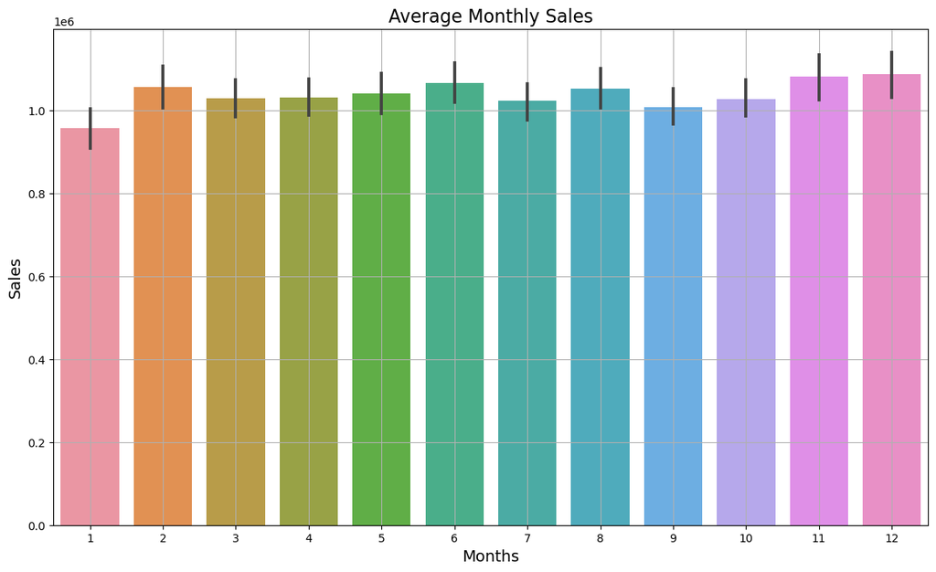

```python
#Average Monthly Sales
plt.figure(figsize=(14,8))
sns.barplot(x='Month',y='Weekly_Sales',data=df)
plt.ylabel('Sales',fontsize=14)
plt.xlabel('Months',fontsize=14)
plt.title('Average Monthly Sales',fontsize=16)
plt.savefig('avg_monthly_sales.png')
plt.grid()
```

```python
# Monthly Sales for Each Year
df_monthly = pd.crosstab(df["Year"], df["Month"], values=df["Weekly_Sales"],aggfunc='sum')
df_monthly
```

| Month Year | 1 | 2 | 3 | 4 | 5 | 6 | 7 | 8 | 9 | 10 | 11 | 12 |
| --- | --- | --- | --- | --- | --- | --- | --- | --- | --- | --- | --- | --- |
| 2010 | 3.982560e+07 | 1.777169e+08 | 1.752329e+08 | 1.732263e+08 | 2.589214e+08 | 1.344962e+08 | 1.739798e+08 | 1.744531e+08 | 1.696679e+08 | 2.106726e+08 | 1.302158e+08 | 2.529080e+08 |
| 2011 | 1.951774e+08 | 1.761004e+08 | 1.285975e+08 | 2.560692e+08 | 1.723317e+08 | 1.320624e+08 | 2.091714e+08 | 1.773939e+08 | 2.069063e+08 | 1.732949e+08 | 2.175282e+08 | 1.687481e+08 |
| 2012 | 1.708155e+08 | 1.428296e+08 | 2.307397e+08 | 1.825428e+08 | 1.422830e+08 | 2.873528e+08 | 1.845865e+08 | 1.916126e+08 | 1.797959e+08 | 1.856164e+08 | 4.692588e+07 | 4.612851e+07 |

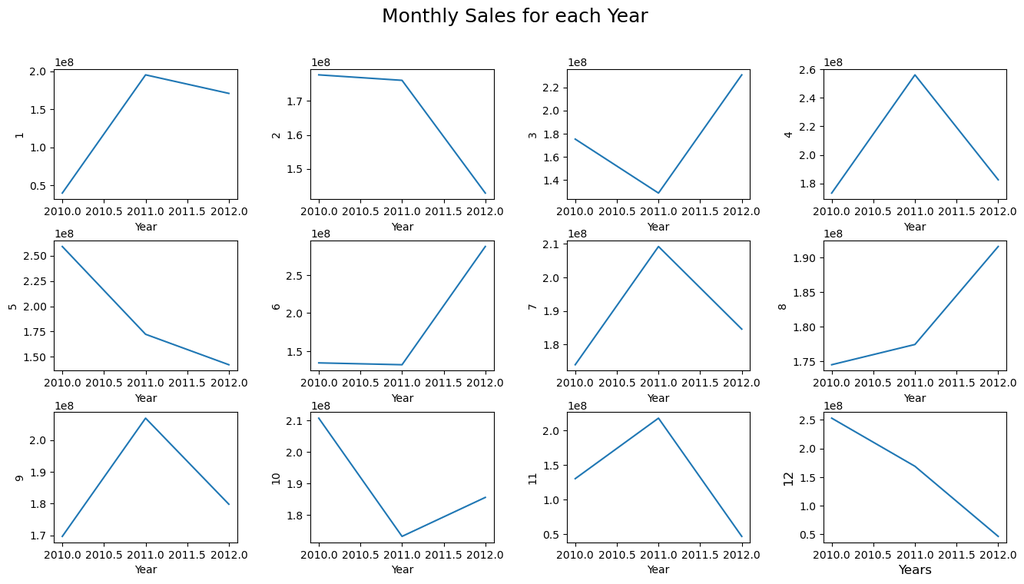

```python
fig, axes = plt.subplots(3,4,figsize=(16,8))
plt.suptitle('Monthly Sales for each Year', fontsize=18)
k=1
for i in range(3):
    for j in range(4):
      sns.lineplot(ax=axes[i,j],data=df_monthly[k])
      plt.subplots_adjust(wspace=0.4,hspace=0.32)
      plt.ylabel(k,fontsize=12)
      plt.xlabel('Years',fontsize=12)
      k+=1

plt.savefig('monthly_sales_every_year.png')
plt.show()
```

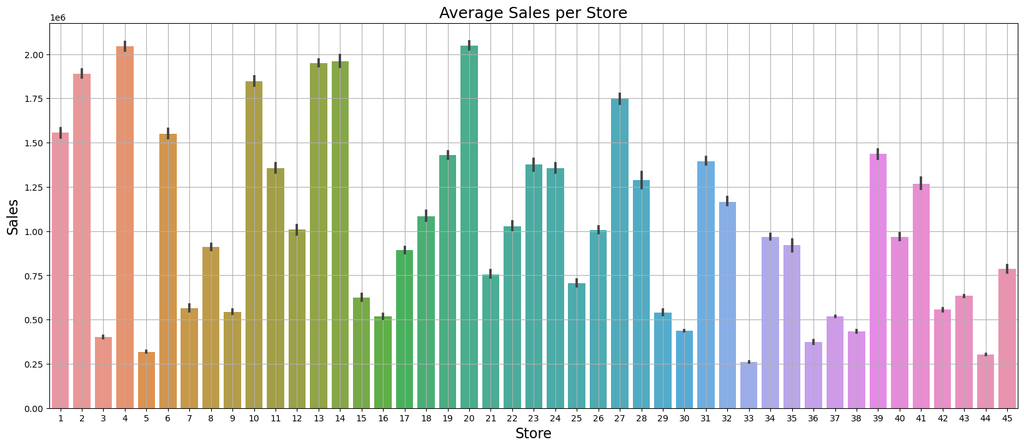

```python
#Average Weekly Sales Store wise
plt.figure(figsize=(20,8))
sns.barplot(x='Store',y='Weekly_Sales',data=df)
plt.grid()
plt.title('Average Sales per Store', fontsize=18)
plt.ylabel('Sales', fontsize=16)
plt.xlabel('Store', fontsize=16)
plt.savefig('avg_sales_store.png')
plt.show()
```

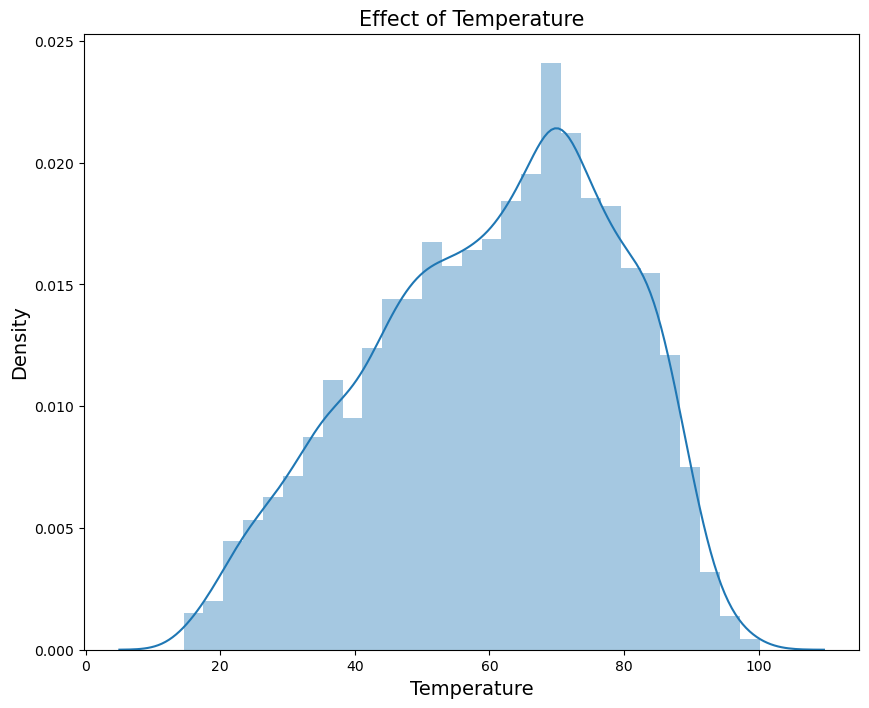

```python
# Effect of Temperature on Sales
plt.figure(figsize=(10,8))
sns.distplot(df['Temperature'])
plt.title('Effect of Temperature',fontsize=15)
plt.xlabel('Temperature',fontsize=14)
plt.ylabel('Density',fontsize=14)
plt.savefig('effect_of_temp.png')
plt.show()
```

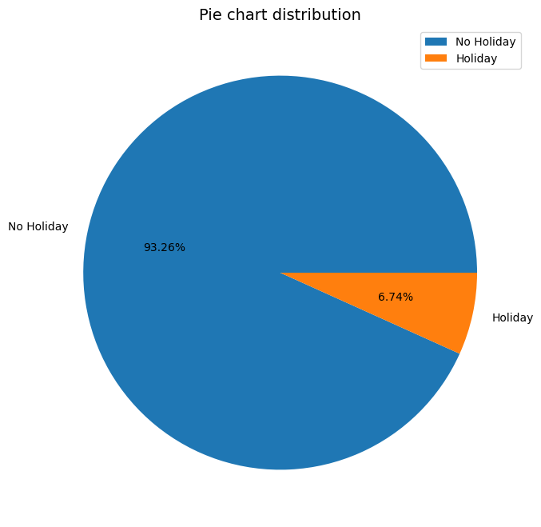

```python
# Holiday Distribution
plt.figure(figsize=(8,8))
plt.pie(df['Holiday_Flag'].value_counts(),labels=['No Holiday','Holiday'],autopct='%0.2f%%')
plt.title("Pie chart distribution",fontsize=14)
plt.legend()
plt.savefig('holiday_distribution.png')
plt.show()
```

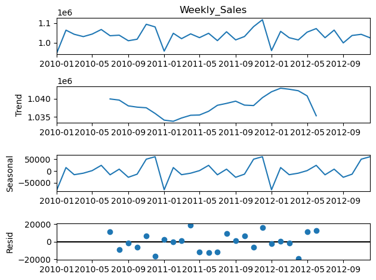

```python
# Time Series Decompose
import statsmodels.api as sm
sm.tsa.seasonal_decompose(df['Weekly_Sales'].resample('MS').mean(), model='additive').plot()
plt.savefig('seasonal_decompose.png')
plt.show()
```

# ONE HOT ENCODING

```python
df.dtypes
```

```
Store                    int64
Date            datetime64[ns]
Weekly_Sales           float64
Holiday_Flag             int64
Temperature            float64
Fuel_Price             float64
CPI                    float64
Unemployment           float64
Year                     int64
Month                    int64
Week                     int64
max                    float64
min                    float64
mean                   float64
median                 float64
std                    float64
dtype: object
```

```python
cat_col = ['Store']
df_cat = df[cat_col].copy()
df_cat.head()
```

| Date | Store |
| --- | --- |
| 2010-01-10 | 5 |
| 2010-01-10 | 22 |
| 2010-01-10 | 30 |
| 2010-01-10 | 37 |
| 2010-01-10 | 3 |

```python
df_cat = pd.get_dummies(df_cat,columns=cat_col)
df_cat.head()
```

| Date | Store_1 | Store_2 | Store_3 | Store_4 | Store_5 | Store_6 | Store_7 | Store_8 | Store_9 | Store_10 | ... | Store_36 | Store_37 | Store_38 | Store_39 | Store_40 | Store_41 | Store_42 | Store_43 | Store_44 | Store_45 |
| --- | --- | --- | --- | --- | --- | --- | --- | --- | --- | --- | --- | --- | --- | --- | --- | --- | --- | --- | --- | --- | --- |
| 2010-01-10 | 0 | 0 | 0 | 0 | 1 | 0 | 0 | 0 | 0 | 0 | ... | 0 | 0 | 0 | 0 | 0 | 0 | 0 | 0 | 0 | 0 |
| 2010-01-10 | 0 | 0 | 0 | 0 | 0 | 0 | 0 | 0 | 0 | 0 | ... | 0 | 0 | 0 | 0 | 0 | 0 | 0 | 0 | 0 | 0 |
| 2010-01-10 | 0 | 0 | 0 | 0 | 0 | 0 | 0 | 0 | 0 | 0 | ... | 0 | 0 | 0 | 0 | 0 | 0 | 0 | 0 | 0 | 0 |
| 2010-01-10 | 0 | 0 | 0 | 0 | 0 | 0 | 0 | 0 | 0 | 0 | ... | 0 | 1 | 0 | 0 | 0 | 0 | 0 | 0 | 0 | 0 |
| 2010-01-10 | 0 | 0 | 1 | 0 | 0 | 0 | 0 | 0 | 0 | 0 | ... | 0 | 0 | 0 | 0 | 0 | 0 | 0 | 0 | 0 | 0 |

5 rows × 45 columns

```python
df.shape
```

```
(6049, 16)
```

```python
df = pd.concat([df, df_cat],axis=1)
```

```python
df
```

| Date | Store | Date | Weekly_Sales | Holiday_Flag | Temperature | Fuel_Price | CPI | Unemployment | Year | Month | ... | Store_36 | Store_37 | Store_38 | Store_39 | Store_40 | Store_41 | Store_42 | Store_43 | Store_44 | Store_45 |
| --- | --- | --- | --- | --- | --- | --- | --- | --- | --- | --- | --- | --- | --- | --- | --- | --- | --- | --- | --- | --- | --- |
| 2010-01-10 | 5 | 2010-01-10 | 283178.12 | 0 | 71.10 | 2.603 | 212.226946 | 6.768 | 2010 | 1 | ... | 0 | 0 | 0 | 0 | 0 | 0 | 0 | 0 | 0 | 0 |
| 2010-01-10 | 22 | 2010-01-10 | 905987.17 | 0 | 69.31 | 2.717 | 136.629757 | 8.572 | 2010 | 1 | ... | 0 | 0 | 0 | 0 | 0 | 0 | 0 | 0 | 0 | 0 |
| 2010-01-10 | 30 | 2010-01-10 | 445475.30 | 0 | 70.28 | 2.603 | 211.329874 | 8.163 | 2010 | 1 | ... | 0 | 0 | 0 | 0 | 0 | 0 | 0 | 0 | 0 | 0 |
| 2010-01-10 | 37 | 2010-01-10 | 529877.93 | 0 | 74.66 | 2.603 | 210.440443 | 8.476 | 2010 | 1 | ... | 0 | 1 | 0 | 0 | 0 | 0 | 0 | 0 | 0 | 0 |
| 2010-01-10 | 3 | 2010-01-10 | 358784.10 | 0 | 73.60 | 2.603 | 214.984655 | 7.564 | 2010 | 1 | ... | 0 | 0 | 0 | 0 | 0 | 0 | 0 | 0 | 0 | 0 |
| ... | ... | ... | ... | ... | ... | ... | ... | ... | ... | ... | ... | ... | ... | ... | ... | ... | ... | ... | ... | ... | ... |
| 2012-12-10 | 18 | 2012-12-10 | 1074079.00 | 0 | 50.97 | 4.029 | 138.911700 | 8.243 | 2012 | 12 | ... | 0 | 0 | 0 | 0 | 0 | 0 | 0 | 0 | 0 | 0 |
| 2012-12-10 | 15 | 2012-12-10 | 551799.63 | 0 | 49.12 | 4.186 | 138.911700 | 7.992 | 2012 | 12 | ... | 0 | 0 | 0 | 0 | 0 | 0 | 0 | 0 | 0 | 0 |
| 2012-12-10 | 29 | 2012-12-10 | 513737.00 | 0 | 54.18 | 4.029 | 138.911700 | 9.151 | 2012 | 12 | ... | 0 | 0 | 0 | 0 | 0 | 0 | 0 | 0 | 0 | 0 |
| 2012-12-10 | 27 | 2012-12-10 | 1660081.29 | 0 | 55.40 | 4.186 | 142.937617 | 8.000 | 2012 | 12 | ... | 0 | 0 | 0 | 0 | 0 | 0 | 0 | 0 | 0 | 0 |
| 2012-12-10 | 2 | 2012-12-10 | 1900745.13 | 0 | 60.97 | 3.601 | 223.015426 | 6.170 | 2012 | 12 | ... | 0 | 0 | 0 | 0 | 0 | 0 | 0 | 0 | 0 | 0 |

6049 rows × 61 columns

```python
df.shape
```

```
(6049, 61)
```

```python
df.drop(columns=cat_col,inplace=True)
```

```python
df.drop(columns=['Date'],inplace=True)
```

```python
df.shape
```

```
(6049, 59)
```

```python
num_col = ['Weekly_Sales','Temperature','Fuel_Price','CPI','Unemployment','max','min','mean','median','std']
```

```python
from sklearn.preprocessing import MinMaxScaler
```

```python
minmax_scale = MinMaxScaler(feature_range=(0, 1))
def normalization(df,col):
  for i in col:
    arr = df[i]
    arr = np.array(arr)
    df[i] = minmax_scale.fit_transform(arr.reshape(len(arr),1))
  return df
```

```python
df.head()
```

| Date | Weekly_Sales | Holiday_Flag | Temperature | Fuel_Price | CPI | Unemployment | Year | Month | Week | max | ... | Store_36 | Store_37 | Store_38 | Store_39 | Store_40 | Store_41 | Store_42 | Store_43 | Store_44 | Store_45 |
| --- | --- | --- | --- | --- | --- | --- | --- | --- | --- | --- | --- | --- | --- | --- | --- | --- | --- | --- | --- | --- | --- |
| 2010-01-10 | 283178.12 | 0 | 71.10 | 2.603 | 212.226946 | 6.768 | 2010 | 1 | 1 | 507900.07 | ... | 0 | 0 | 0 | 0 | 0 | 0 | 0 | 0 | 0 | 0 |
| 2010-01-10 | 905987.17 | 0 | 69.31 | 2.717 | 136.629757 | 8.572 | 2010 | 1 | 1 | 1962445.04 | ... | 0 | 0 | 0 | 0 | 0 | 0 | 0 | 0 | 0 | 0 |
| 2010-01-10 | 445475.30 | 0 | 70.28 | 2.603 | 211.329874 | 8.163 | 2010 | 1 | 1 | 519354.88 | ... | 0 | 0 | 0 | 0 | 0 | 0 | 0 | 0 | 0 | 0 |
| 2010-01-10 | 529877.93 | 0 | 74.66 | 2.603 | 210.440443 | 8.476 | 2010 | 1 | 1 | 605791.46 | ... | 0 | 1 | 0 | 0 | 0 | 0 | 0 | 0 | 0 | 0 |
| 2010-01-10 | 358784.10 | 0 | 73.60 | 2.603 | 214.984655 | 7.564 | 2010 | 1 | 1 | 605990.41 | ... | 0 | 0 | 0 | 0 | 0 | 0 | 0 | 0 | 0 | 0 |

5 rows × 59 columns

```python
df = normalization(df.copy(),num_col)
df.head()
```

| Date | Weekly_Sales | Holiday_Flag | Temperature | Fuel_Price | CPI | Unemployment | Year | Month | Week | max | ... | Store_36 | Store_37 | Store_38 | Store_39 | Store_40 | Store_41 | Store_42 | Store_43 | Store_44 | Store_45 |
| --- | --- | --- | --- | --- | --- | --- | --- | --- | --- | --- | --- | --- | --- | --- | --- | --- | --- | --- | --- | --- | --- |
| 2010-01-10 | 0.032929 | 0 | 0.660668 | 0.065631 | 0.851675 | 0.347737 | 2010 | 1 | 1 | 0.050674 | ... | 0 | 0 | 0 | 0 | 0 | 0 | 0 | 0 | 0 | 0 |
| 2010-01-10 | 0.313126 | 0 | 0.639752 | 0.122745 | 0.104437 | 0.564877 | 2010 | 1 | 1 | 0.467746 | ... | 0 | 0 | 0 | 0 | 0 | 0 | 0 | 0 | 0 | 0 |
| 2010-01-10 | 0.105945 | 0 | 0.651087 | 0.065631 | 0.842808 | 0.515648 | 2010 | 1 | 1 | 0.053959 | ... | 0 | 0 | 0 | 0 | 0 | 0 | 0 | 0 | 0 | 0 |
| 2010-01-10 | 0.143917 | 0 | 0.702267 | 0.065631 | 0.834016 | 0.553322 | 2010 | 1 | 1 | 0.078743 | ... | 0 | 1 | 0 | 0 | 0 | 0 | 0 | 0 | 0 | 0 |
| 2010-01-10 | 0.066943 | 0 | 0.689881 | 0.065631 | 0.878934 | 0.443548 | 2010 | 1 | 1 | 0.078800 | ... | 0 | 0 | 0 | 0 | 0 | 0 | 0 | 0 | 0 | 0 |

5 rows × 59 columns

# Finding Correlation between features

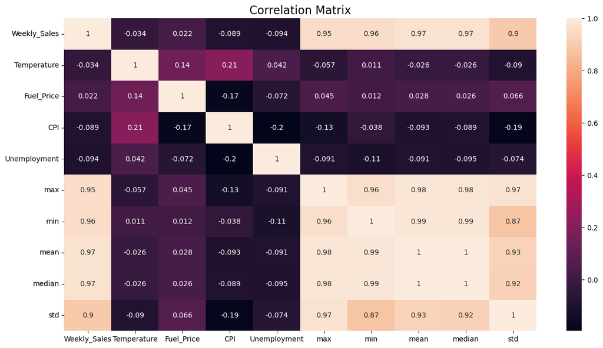

```python
plt.figure(figsize=(15,8))
corr = df[num_col].corr()
sns.heatmap(corr,vmax=1.0,annot=True)
plt.title('Correlation Matrix',fontsize=16)
plt.savefig('correlation_matrix.png')
plt.show()
```

# Feature Elimination

```python
feature_col = df.columns.difference(['Weekly_Sales'])
feature_col
```

```
Index(['CPI', 'Fuel_Price', 'Holiday_Flag', 'Month', 'Store_1', 'Store_10',
       'Store_11', 'Store_12', 'Store_13', 'Store_14', 'Store_15', 'Store_16',
       'Store_17', 'Store_18', 'Store_19', 'Store_2', 'Store_20', 'Store_21',
       'Store_22', 'Store_23', 'Store_24', 'Store_25', 'Store_26', 'Store_27',
       'Store_28', 'Store_29', 'Store_3', 'Store_30', 'Store_31', 'Store_32',
       'Store_33', 'Store_34', 'Store_35', 'Store_36', 'Store_37', 'Store_38',
       'Store_39', 'Store_4', 'Store_40', 'Store_41', 'Store_42', 'Store_43',
       'Store_44', 'Store_45', 'Store_5', 'Store_6', 'Store_7', 'Store_8',
       'Store_9', 'Temperature', 'Unemployment', 'Week', 'Year', 'max', 'mean',
       'median', 'min', 'std'],
      dtype='object')
```

```python
from sklearn import metrics
from sklearn.model_selection import train_test_split
from sklearn.linear_model import LinearRegression

from sklearn.ensemble import RandomForestRegressor
from sklearn.neighbors import KNeighborsRegressor
```

```python
radm_clf = RandomForestRegressor(oob_score=True,n_estimators=23)
radm_clf.fit(df[feature_col], df['Weekly_Sales'])
```

```
RandomForestRegressor(n_estimators=23, oob_score=True)
```

```python
indices = np.argsort(radm_clf.feature_importances_)[::-1]
feature_rank = pd.DataFrame(columns = ['rank', 'feature', 'importance'])

for f in range(df[feature_col].shape[1]):
    feature_rank.loc[f] = [f+1,
                           df[feature_col].columns[indices[f]],
                           radm_clf.feature_importances_[indices[f]]]

feature_rank
```

|  | rank | feature | importance |
| --- | --- | --- | --- |
| 0 | 1 | median | 3.845505e-01 |
| 1 | 2 | min | 2.757331e-01 |
| 2 | 3 | mean | 2.450532e-01 |
| 3 | 4 | max | 3.893442e-02 |
| 4 | 5 | Week | 1.967216e-02 |
| 5 | 6 | Temperature | 8.882483e-03 |
| 6 | 7 | CPI | 8.237062e-03 |
| 7 | 8 | Fuel_Price | 6.264859e-03 |
| 8 | 9 | Unemployment | 5.787133e-03 |
| 9 | 10 | Month | 2.914453e-03 |
| 10 | 11 | Holiday_Flag | 1.505849e-03 |
| 11 | 12 | Year | 8.310619e-04 |
| 12 | 13 | std | 6.381142e-04 |
| 13 | 14 | Store_32 | 2.768397e-04 |
| 14 | 15 | Store_27 | 1.580134e-04 |
| 15 | 16 | Store_36 | 6.866169e-05 |
| 16 | 17 | Store_18 | 5.675805e-05 |
| 17 | 18 | Store_17 | 5.382211e-05 |
| 18 | 19 | Store_35 | 5.039340e-05 |
| 19 | 20 | Store_11 | 2.964595e-05 |
| 20 | 21 | Store_39 | 2.755006e-05 |
| 21 | 22 | Store_13 | 1.866691e-05 |
| 22 | 23 | Store_7 | 1.831543e-05 |
| 23 | 24 | Store_34 | 1.829538e-05 |
| 24 | 25 | Store_1 | 1.767499e-05 |
| 25 | 26 | Store_41 | 1.633659e-05 |
| 26 | 27 | Store_6 | 1.630651e-05 |
| 27 | 28 | Store_33 | 1.445854e-05 |
| 28 | 29 | Store_31 | 1.401350e-05 |
| 29 | 30 | Store_16 | 1.366976e-05 |
| 30 | 31 | Store_23 | 1.098642e-05 |
| 31 | 32 | Store_42 | 1.088954e-05 |
| 32 | 33 | Store_22 | 9.976517e-06 |
| 33 | 34 | Store_9 | 8.103709e-06 |
| 34 | 35 | Store_43 | 8.066178e-06 |
| 35 | 36 | Store_26 | 7.183358e-06 |
| 36 | 37 | Store_3 | 6.868548e-06 |
| 37 | 38 | Store_21 | 6.472569e-06 |
| 38 | 39 | Store_2 | 5.989185e-06 |
| 39 | 40 | Store_29 | 5.843894e-06 |
| 40 | 41 | Store_10 | 5.489809e-06 |
| 41 | 42 | Store_24 | 4.079673e-06 |
| 42 | 43 | Store_15 | 3.845057e-06 |
| 43 | 44 | Store_30 | 3.182875e-06 |
| 44 | 45 | Store_37 | 3.148654e-06 |
| 45 | 46 | Store_28 | 3.083607e-06 |
| 46 | 47 | Store_19 | 3.052444e-06 |
| 47 | 48 | Store_44 | 2.724710e-06 |
| 48 | 49 | Store_20 | 2.711845e-06 |
| 49 | 50 | Store_8 | 2.690962e-06 |
| 50 | 51 | Store_40 | 2.654768e-06 |
| 51 | 52 | Store_25 | 2.263131e-06 |
| 52 | 53 | Store_14 | 2.145503e-06 |
| 53 | 54 | Store_12 | 1.846299e-06 |
| 54 | 55 | Store_4 | 1.820954e-06 |
| 55 | 56 | Store_45 | 6.502544e-07 |
| 56 | 57 | Store_38 | 3.006638e-07 |
| 57 | 58 | Store_5 | 4.968151e-08 |

```python
x=feature_rank.loc[0:25,['feature']]
x=x['feature'].tolist()
print(x)
```

```
['median', 'min', 'mean', 'max', 'Week', 'Temperature', 'CPI', 'Fuel_Price', 'Unemployment', 'Month', 'Holiday_Flag', 'Year', 'std', 'Store_32', 'Store_27', 'Store_36', 'Store_18', 'Store_17', 'Store_35', 'Store_11', 'Store_39', 'Store_13', 'Store_7', 'Store_34', 'Store_1', 'Store_41']
```

```python
X = df[x]
Y = df['Weekly_Sales']
```

```python
df = pd.concat([X,Y],axis=1)
df.head()
```

| Date | median | min | mean | max | Week | Temperature | CPI | Fuel_Price | Unemployment | Month | ... | Store_17 | Store_35 | Store_11 | Store_39 | Store_13 | Store_7 | Store_34 | Store_1 | Store_41 | Weekly_Sales |
| --- | --- | --- | --- | --- | --- | --- | --- | --- | --- | --- | --- | --- | --- | --- | --- | --- | --- | --- | --- | --- | --- |
| 2010-01-10 | 0.028593 | 0.032624 | 0.031470 | 0.050674 | 1 | 0.660668 | 0.851675 | 0.065631 | 0.347737 | 1 | ... | 0 | 0 | 0 | 0 | 0 | 0 | 0 | 0 | 0 | 0.032929 |
| 2010-01-10 | 0.406605 | 0.363450 | 0.415972 | 0.467746 | 1 | 0.639752 | 0.104437 | 0.122745 | 0.564877 | 1 | ... | 0 | 0 | 0 | 0 | 0 | 0 | 0 | 0 | 0 | 0.313126 |
| 2010-01-10 | 0.098947 | 0.102886 | 0.096719 | 0.053959 | 1 | 0.651087 | 0.842808 | 0.065631 | 0.515648 | 1 | ... | 0 | 0 | 0 | 0 | 0 | 0 | 0 | 0 | 0 | 0.105945 |
| 2010-01-10 | 0.143042 | 0.155448 | 0.140186 | 0.078743 | 1 | 0.702267 | 0.834016 | 0.065631 | 0.553322 | 1 | ... | 0 | 0 | 0 | 0 | 0 | 0 | 0 | 0 | 0 | 0.143917 |
| 2010-01-10 | 0.075284 | 0.083483 | 0.077304 | 0.078800 | 1 | 0.689881 | 0.878934 | 0.065631 | 0.443548 | 1 | ... | 0 | 0 | 0 | 0 | 0 | 0 | 0 | 0 | 0 | 0.066943 |

5 rows × 27 columns

# 5.Choosing the Algorithm for the Project

# Building the models

Splitting data into train and test data

```python
X = df.drop(['Weekly_Sales'],axis=1)
Y = df.Weekly_Sales
```

```python
X_train,X_test,y_train,y_test = train_test_split(X,Y,test_size=0.20, random_state=50)
```

# Linear Regression Model

```python
lr = LinearRegression()
lr.fit(X_train, y_train)
```

```
LinearRegression()
```

```python
linear_regression_accuracy = lr.score(X_test,y_test)*100
print("Linear Regressor Accuracy - ",linear_regression_accuracy)
```

```
Linear Regressor Accuracy -  95.10438666829518
```

```python
y_pred = lr.predict(X_test)
```

```python
print("MAE" , metrics.mean_absolute_error(y_test, y_pred))
print("MSE" , metrics.mean_squared_error(y_test, y_pred))
print("RMSE" , np.sqrt(metrics.mean_squared_error(y_test, y_pred)))
print("R2" , metrics.explained_variance_score(y_test, y_pred))
```

```
MAE 0.03612374195578505
MSE 0.002849901091362807
RMSE 0.05338446488785672
R2 0.9511872767448203
```

```python
lr_df = pd.DataFrame({'Actual': y_test, 'Predicted': y_pred})
lr_df.head()
```

| Date | Actual | Predicted |
| --- | --- | --- |
| 2012-04-05 | 0.521995 | 0.515101 |
| 2011-07-01 | 0.134812 | 0.199151 |
| 2012-04-05 | 0.109995 | 0.100777 |
| 2011-09-16 | 0.327268 | 0.373187 |
| 2011-01-14 | 0.255174 | 0.376600 |

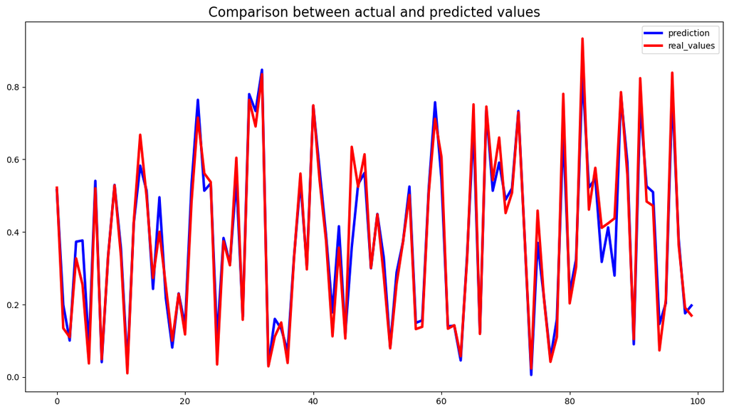

```python
plt.figure(figsize=(15,8))
plt.title('Comparison between actual and predicted values',fontsize=16)
plt.plot(lr.predict(X_test[:100]), label="prediction", linewidth=3.0,color='blue')
plt.plot(y_test[:100].values, label="real_values", linewidth=3.0,color='red')
plt.legend(loc="best")
#plt.savefig('lr_real_pred.png')
plt.show()
```

# Random Forest Regressor

```python
rf = RandomForestRegressor()
rf.fit(X_train, y_train)
```

```
RandomForestRegressor()
```

```python
random_forest_accuracy = rf.score(X_test,y_test)*100
print("Random Forest Regressor Accuracy - ",random_forest_accuracy)
```

```
Random Forest Regressor Accuracy -  97.6508427703329
```

```python
y_pred = rf.predict(X_test)
```

```python
print("MAE" , metrics.mean_absolute_error(y_test, y_pred))
print("MSE" , metrics.mean_squared_error(y_test, y_pred))
print("RMSE" , np.sqrt(metrics.mean_squared_error(y_test, y_pred)))
print("R2" , metrics.explained_variance_score(y_test, y_pred))
```

```
MAE 0.024365484868437336
MSE 0.0013675233926776838
RMSE 0.036980040463440327
R2 0.976509672248957
```

```python
rf_df = pd.DataFrame({'Actual': y_test, 'Predicted': y_pred})
rf_df.head()
```

| Date | Actual | Predicted |
| --- | --- | --- |
| 2012-04-05 | 0.521995 | 0.524511 |
| 2011-07-01 | 0.134812 | 0.161662 |
| 2012-04-05 | 0.109995 | 0.100760 |
| 2011-09-16 | 0.327268 | 0.330910 |
| 2011-01-14 | 0.255174 | 0.311992 |

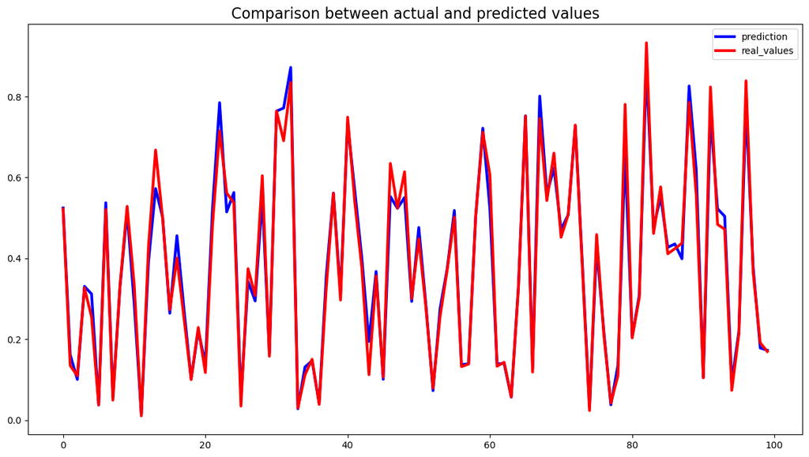

```python
plt.figure(figsize=(15,8))
plt.title('Comparison between actual and predicted values',fontsize=16)
plt.plot(rf.predict(X_test[:100]), label="prediction", linewidth=3.0,color='blue')
plt.plot(y_test[:100].values, label="real_values", linewidth=3.0,color='red')
plt.legend(loc="best")
# plt.savefig('rf_real_pred.png')
plt.show()
```

# KNN

```python
knn = KNeighborsRegressor(n_neighbors = 1,weights = 'uniform')
knn.fit(X_train,y_train)
```

```
KNeighborsRegressor(n_neighbors=1)
```

```python
knn_accuracy = knn.score(X_test, y_test)*100
print("KNeigbhbors Regressor Accuracy - ",knn_accuracy)
```

```
KNeigbhbors Regressor Accuracy -  90.23378032199662
```

```python
y_pred = knn.predict(X_test)
```

```python
print("MAE" , metrics.mean_absolute_error(y_test, y_pred))
print("MSE" , metrics.mean_squared_error(y_test, y_pred))
print("RMSE" , np.sqrt(metrics.mean_squared_error(y_test, y_pred)))
print("R2" , metrics.explained_variance_score(y_test, y_pred))
```

```
MAE 0.05557076236440488
MSE 0.005685244775885586
RMSE 0.07540056217221186
R2 0.9023435854863396
```

```python
knn_df = pd.DataFrame({'Actual': y_test, 'Predicted': y_pred})
knn_df.head()
```

| Date | Actual | Predicted |
| --- | --- | --- |
| 2012-04-05 | 0.521995 | 0.568110 |
| 2011-07-01 | 0.134812 | 0.172292 |
| 2012-04-05 | 0.109995 | 0.146362 |
| 2011-09-16 | 0.327268 | 0.333633 |
| 2011-01-14 | 0.255174 | 0.306450 |

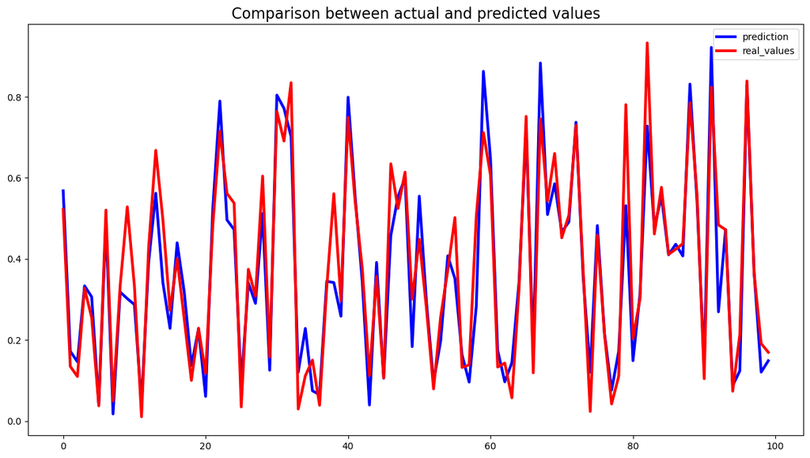

```python
plt.figure(figsize=(15,8))
plt.title('Comparison between actual and predicted values',fontsize=16)
plt.plot(knn.predict(X_test[:100]), label="prediction", linewidth=3.0,color='blue')
plt.plot(y_test[:100].values, label="real_values", linewidth=3.0,color='red')
plt.legend(loc="best")
#plt.savefig('knn_real_pred.png')
plt.show()
```

# Comparing accuracy of models

```python
acc = {'model':['linear_regression_accuracy','random_forest_accuracy','knn_accuracy'],'accuracy':[linear_regression_accuracy,random_forest_accuracy,knn_accuracy]}
```

```python
acc_df = pd.DataFrame(acc)
acc_df
```

|  | model | accuracy |
| --- | --- | --- |
| 0 | linear_regression_accuracy | 95.104387 |
| 1 | random_forest_accuracy | 97.650843 |
| 2 | knn_accuracy | 90.233780 |

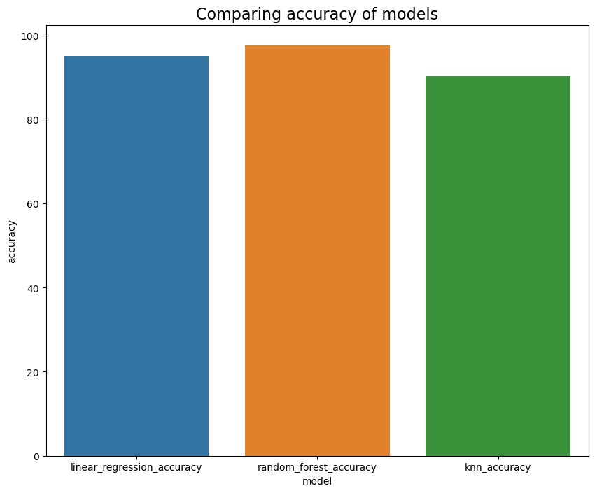

```python
plt.figure(figsize=(10,8))
plt.title('Comparing accuracy of models',fontsize=16)
sns.barplot(x='model',y='accuracy',data=acc_df)
plt.savefig('models_comparison.png')
plt.show()
```